# QUELLE ACTIVITÉ À LA MÉDIATHÈQUE LA SEMAINE DERNIÈRE ?

```
Dernière mise à jour le 01-10-2026 à 10h24
```

## Quel était le nombre d'inscriptions

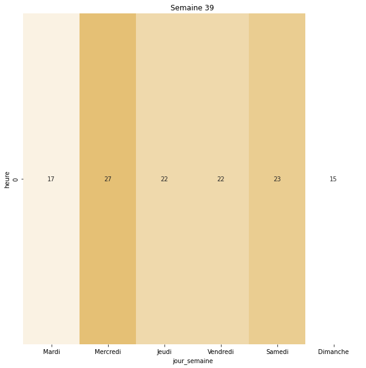

# Quel était le nombre d'entrées ?

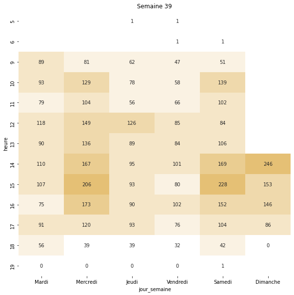

> **Comment lire ce graphique ?** Il s'agit ici du nombre total d'entrées par heure et par jour de la semaine. Plus le chiffre se rapproche de la valeur maximum, plus la case est foncée. On trouve sur l'axe vertical, l'heure concernée. Exemple : 9 coreespond à la neuvième heure, soit le total d'entrées enregistrées entre 9h00 et 9h59.

# Quel était le nombre de réservations effectuées ?

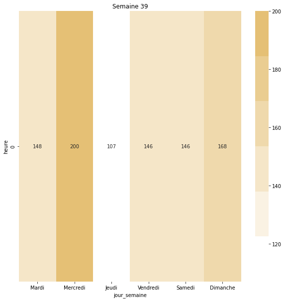

# Quel était le nombre de connexions aux ordinateurs ?

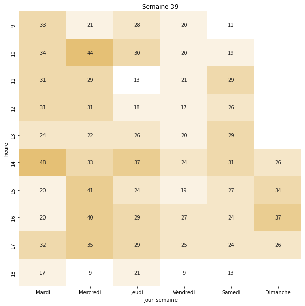

# Quel était le nombre d'impressions ?

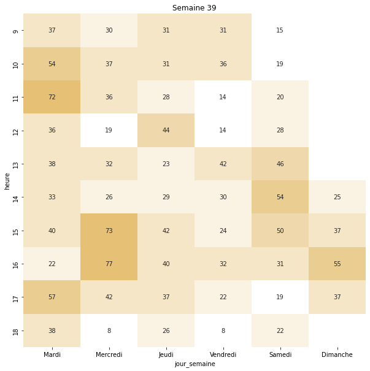

# Quel était le nombre de connexions au wifi ?

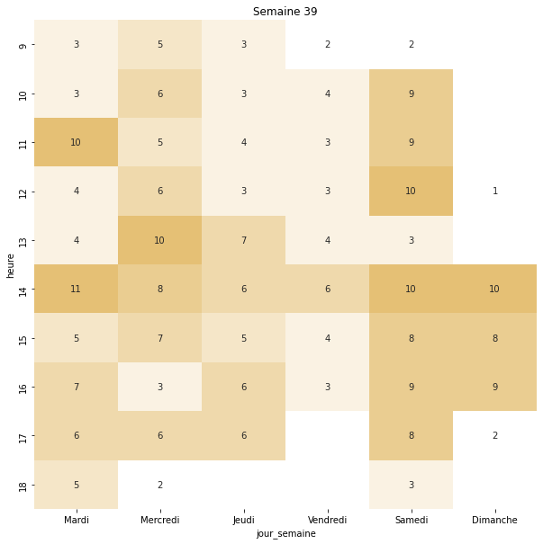

# Quel était le nombre de prêts/retours par heure et par jour ?

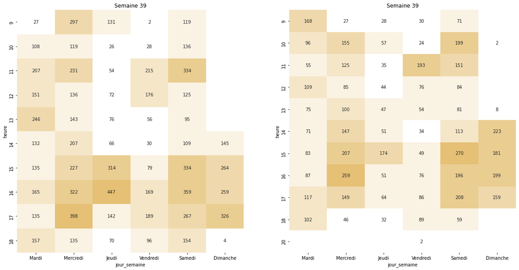

# SYNTHÈSE DES DONNÉES DE COMPTAGE

Depuis octobre 2023, la médiathèque de Roubaix a décidé d'effectuer une analyse plus régulière de la fréquentation des espaces. L'indicateur des `entrées` ne permettant pas d'avoir une idée suffisamment représentative de l'activité et de l'occupation des différents espaces.

Il a été décidé de récolter de manière régulière des données en utilisant plusieurs indicateurs :

- `espace` : ce sont les espaces ouverts au publics à la médiathèque
- `nb_personnes_assises` : le nombre de personnes assises
- `nb_personnes_debout` : le nombre de personnes debout
- `horaire` : c'est l'horaire auquel est effectué le comptage (de 9h30 à 18h30 du mardi au samedi et de 14h30 à 17h30 le dimanche)
- `date`: la date à laquelle est effectuée le comptage
- `jour` : le jour de la semaine auquel est effectué le comptage

Et 2 indicateurs supplémentaires produits pour l'analyse de l'occupation des espaces :

- `nb_personnes_totales` : c'est la somme des personnes assises et des personnes debout dans un espace
- `tx_occupation_places` : c'est le Nb de personnes assises divisé par le nb de places disponibles

**Avec quelle régularité est effectué le comptage ?**

Le comptage de la fréquentation s'effectue entre chaque période de vacances scolaire

**Combien de temps dure le comptage ?**  
Le comptage se déroule sur une semaine complète, du mardi au dimanche

**Comment est effectué le comptage ?**

La semaine précédent le comptage, le responsable du projet invite par mail les collègues à remplir un planning de comptage (sur base du volontariat). Une fiche de comptage est prévue (support papier) pour inscrire le nombre de personnes (assises et debout) dans chaque espace ouvert au public (rez-de-chaussée, Lac, Jeunesse, Salle d'étude, Phare et salle multimédia).

Le comptage s'effectue toutes les heures entre 9h30 et 18h30.

**Ce qu'il reste à faire**

- [x] Ajouter à la classe `Comptage` un filtre pour ne garder que les horaires d'ouverture au public par espace)
- [ ] Masquer les bordures des figures quand un ax n'est pas rempli
- [ ] Réviser les variables Nb de places assises et les intégrer dans la classe Comptage
- [ ] Documenter la classe `Comptage`

```
NOMBRE DE PLACES ASSISES
-------------------------
Café : 42
Rez-de-chaussée : 61
Lac : 68
Salle d'étude : 33
Jeunesse : 48
Phare : 32
Salle Multimédia : 18
```

# SYNTHÈSE DU COMPTAGE DANS LES ESPACES

## Rez-de-chaussée

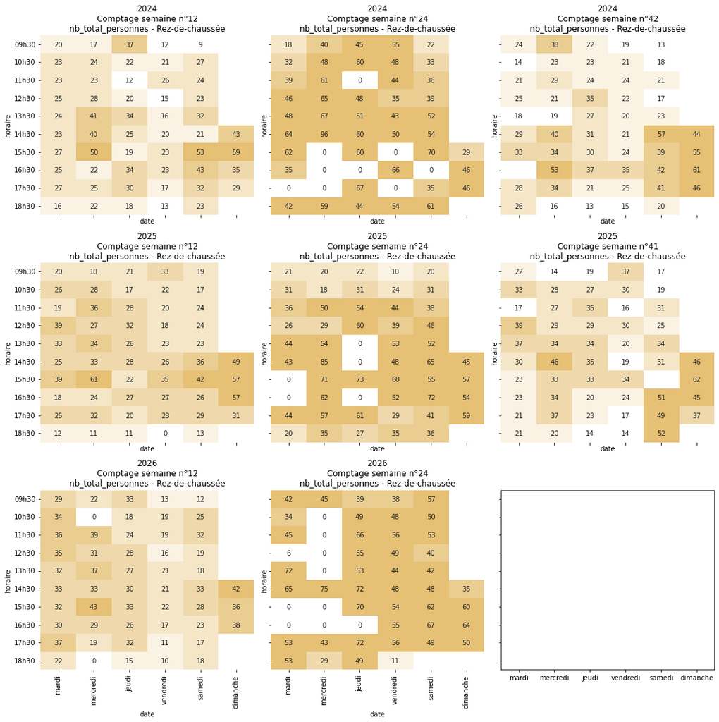

## Rez-de-chaussée étendu (Patio + La Criée + Rez-de-chaussée)

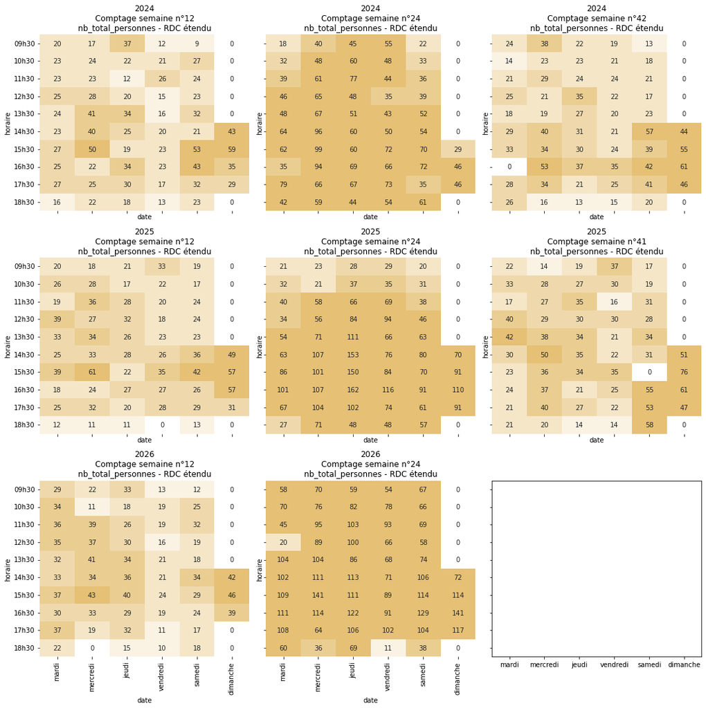

## Lac

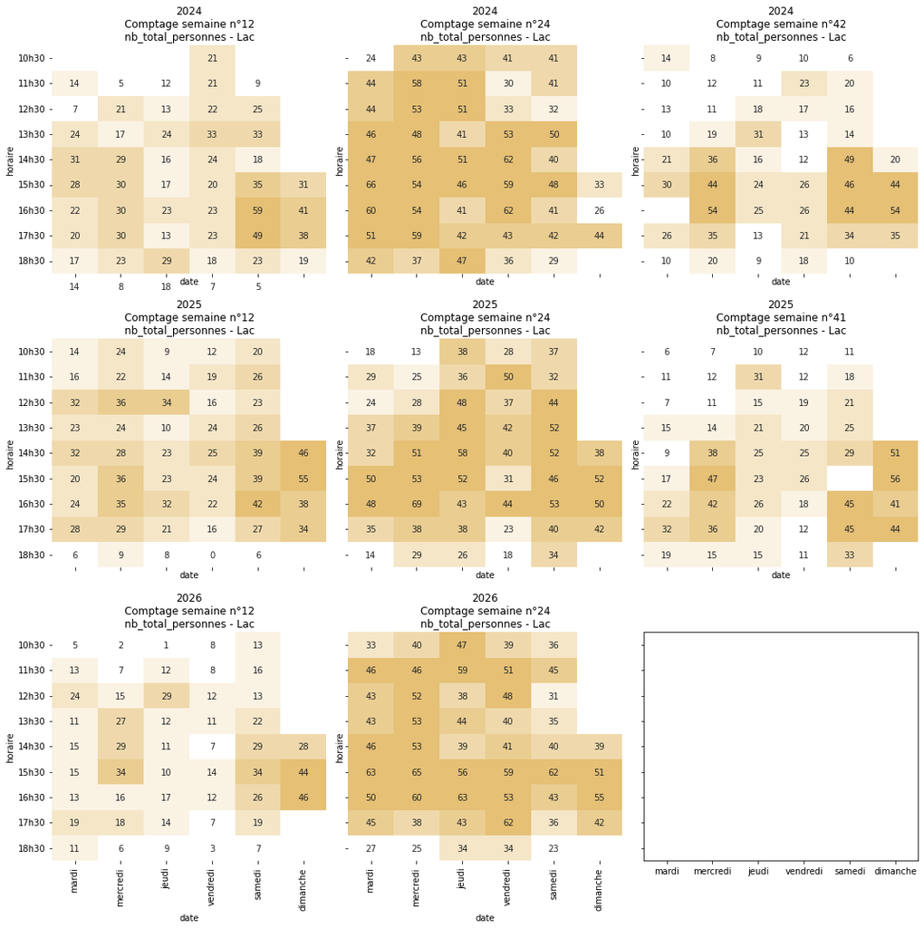

## Jeunesse

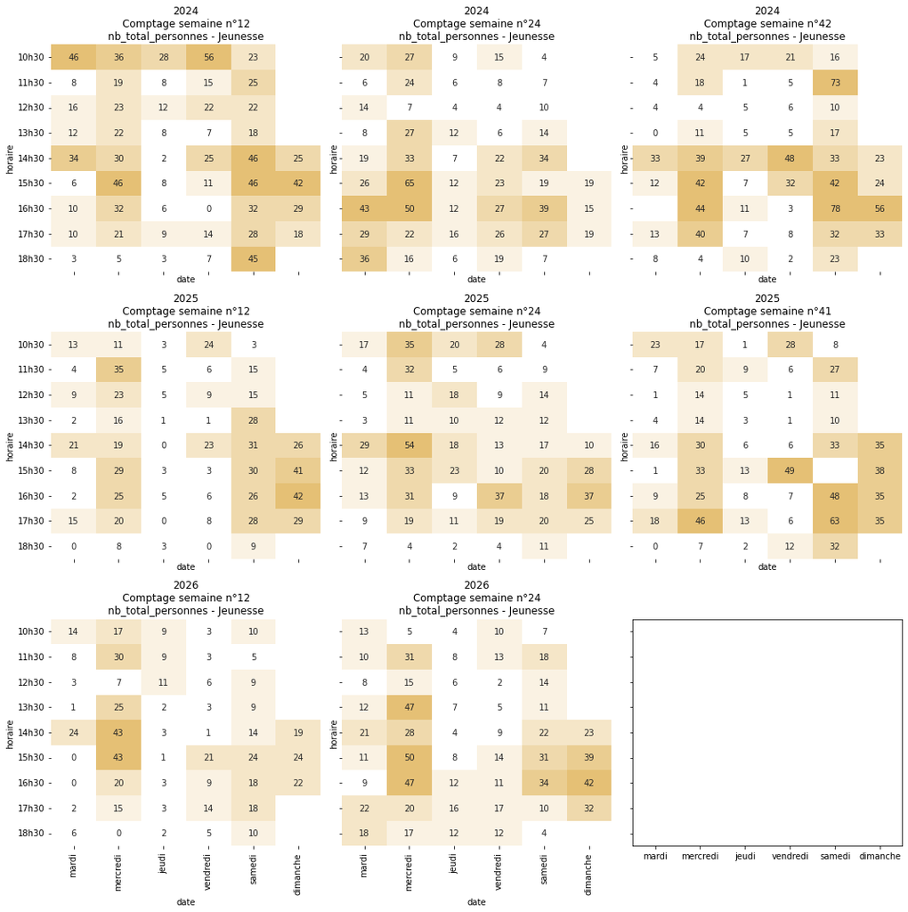

## Salle d'étude

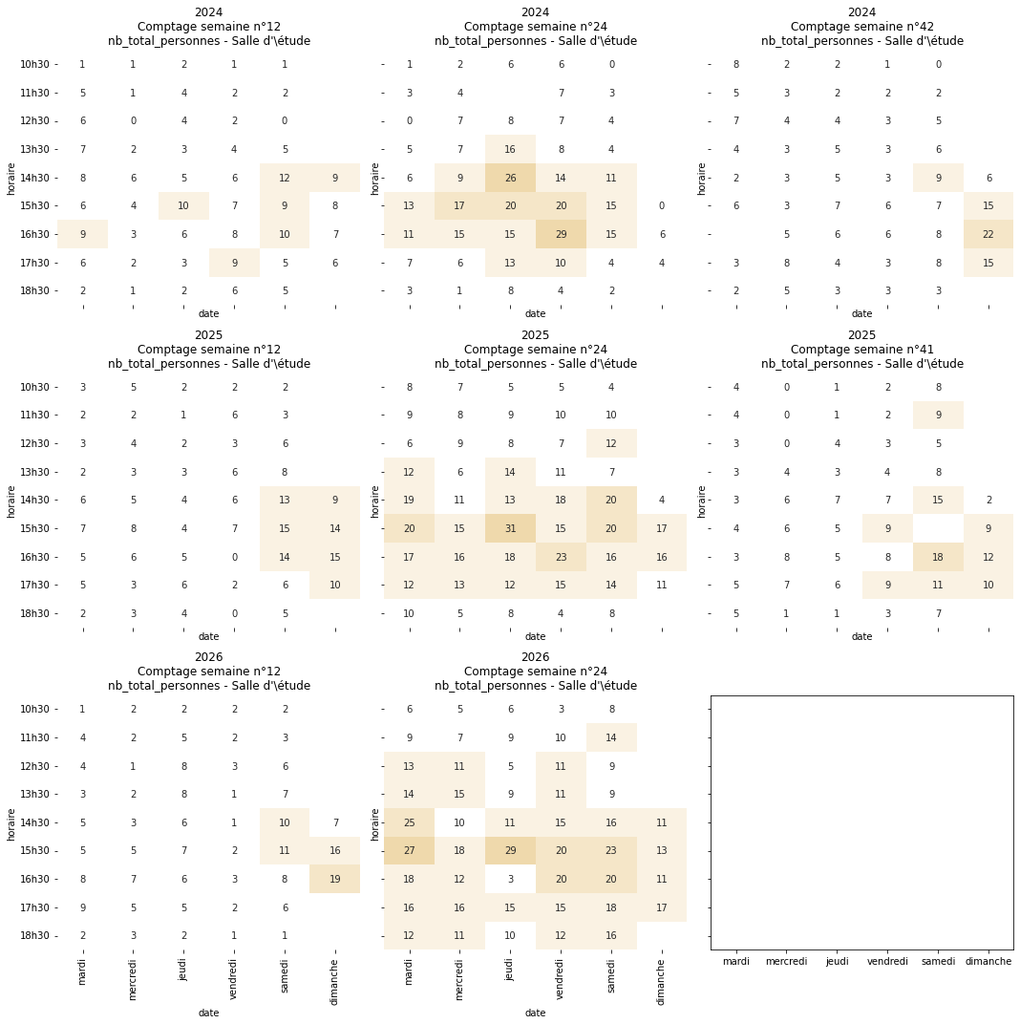

## Phare

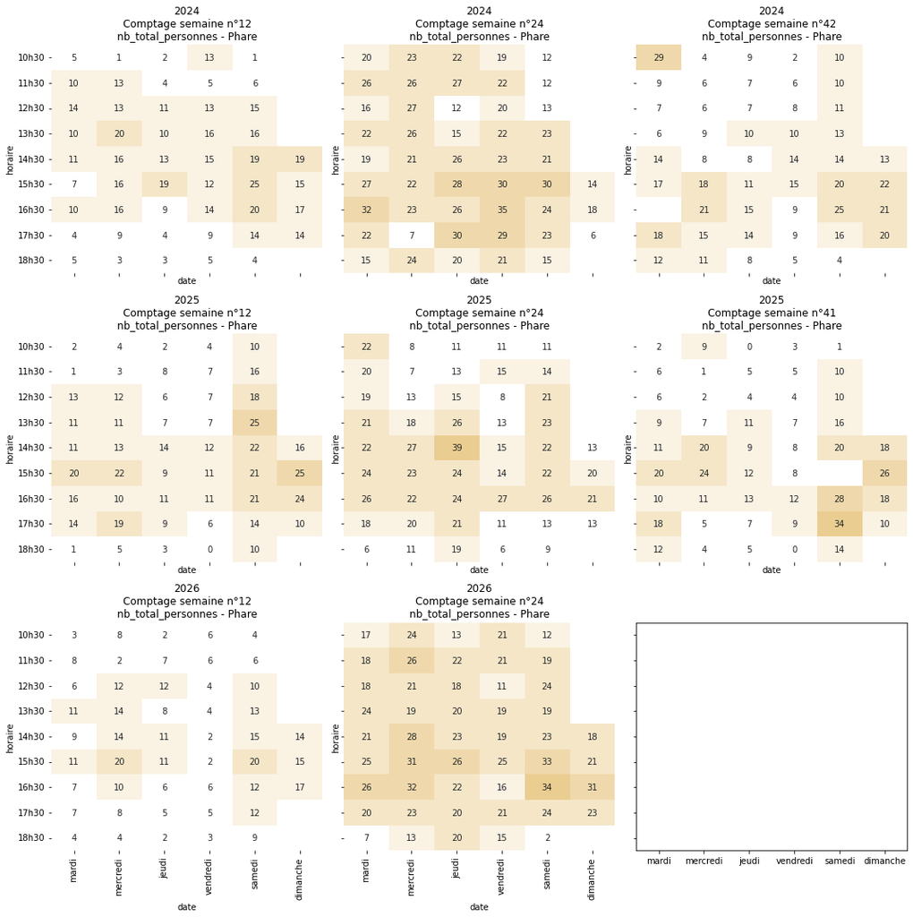

## Salle Multimédia

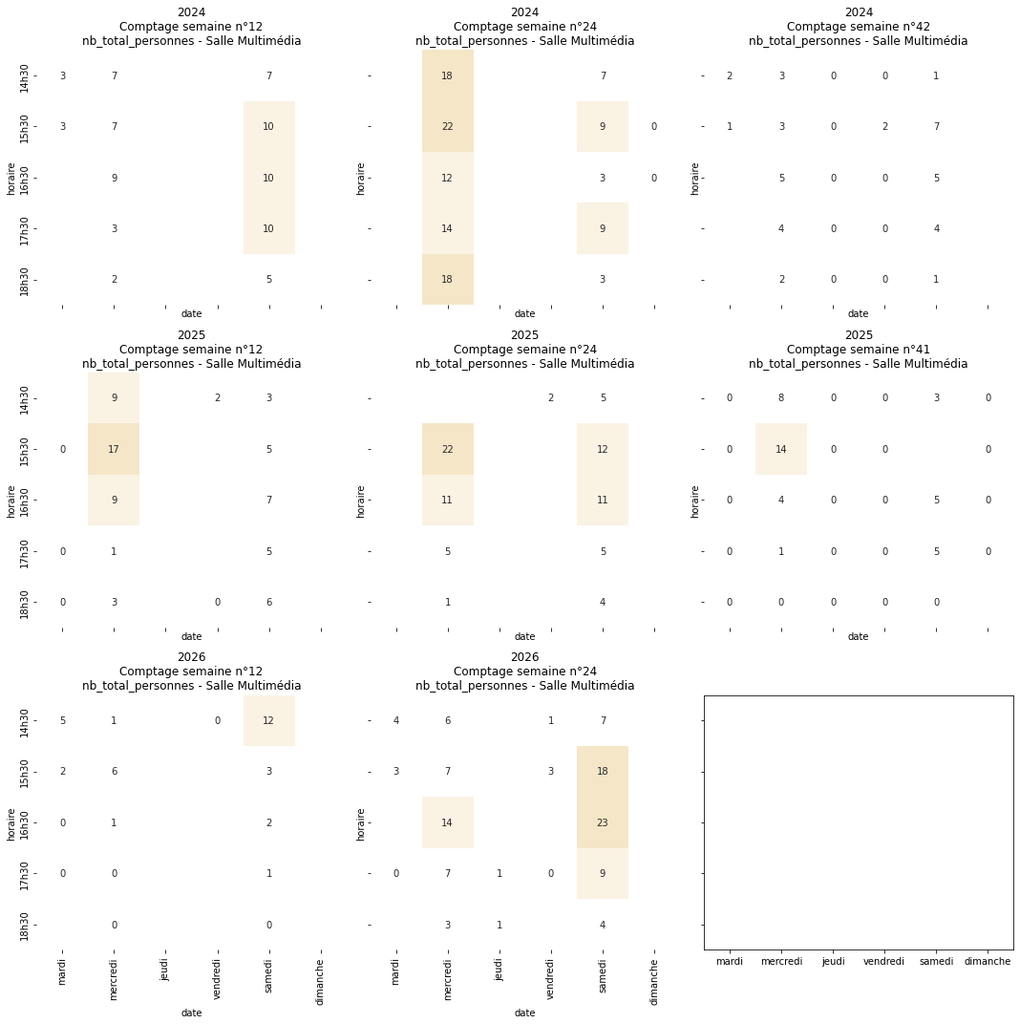